# Elsevier 2022 SDG mapping

OR

(

TITLE-ABS("pest management") AND (TITLE-ABS("sustainable") OR TITLE-ABS("renewable"))

)

OR

(

AUTHKEY("pest management") AND (AUTHKEY("sustainable") OR AUTHKEY("renewable"))

)

OR TITLE-ABS

(

"organic standards"

)

OR AUTHKEY

(

"organic standards"

)

OR

(

(TITLE-ABS("agri*-environmental* program*") OR TITLE-ABS("agri*-environmental* polic*") OR TITLE-ABS("agri*-environmental* scheme*") OR TITLE-ABS("agri*-environmental* measure*")) OR (TITLE-ABS("agrienvironmental* program*") OR TITLE-ABS("agrienvironmental* polic*") OR TITLE-ABS("agrienvironmental* scheme*") OR TITLE-ABS("agrienvironmental* measure*"))

)

OR

(

(AUTHKEY("agri*-environmental* program*") OR AUTHKEY("agri*-environmental* polic*") OR AUTHKEY("agri*-environmental* scheme*") OR AUTHKEY("agri*-environmental* measure*")) OR (AUTHKEY("agrienvironmental* program*") OR AUTHKEY("agrienvironmental* polic*") OR AUTHKEY("agrienvironmental* scheme*") OR AUTHKEY("agrienvironmental* measure*"))

)

OR TITLE-ABS

(

"organic management"

)

OR AUTHKEY

(

"organic management"

)

OR

(

TITLE-ABS("crop-livestock system") OR TITLE-ABS("croplivestock system")

)

OR

(

AUTHKEY("crop-livestock system") OR AUTHKEY("croplivestock system")

)

OR TITLE-ABS

(

"conversion to organic"

)

OR AUTHKEY

(

"conversion to organic"

)

OR TITLE-ABS

(

"intercrop*"

)

OR AUTHKEY

(

"intercrop*"

)

OR TITLE-ABS

(

"agriculture wireless sensor networks"

)

OR AUTHKEY

(

"agriculture wireless sensor networks"

)

OR TITLE-ABS

(

"integrated pest management"

)

OR AUTHKEY

(

"integrated pest management"

)

OR

(

TITLE-ABS("bacter* resistan*") AND (TITLE-ABS("crop*") OR TITLE-ABS("agri*") OR TITLE-ABS("agro*") OR TITLE-ABS("farm*"))

)

OR

(

AUTHKEY("bacter* resistan*") AND (AUTHKEY("crop*") OR AUTHKEY("agri*") OR AUTHKEY("agro*") OR AUTHKEY("farm*"))

)

OR TITLE-ABS

(

"natural enemy"

)

OR AUTHKEY

(

"natural enemy"

)

OR

(

TITLE-ABS("site-specific crop management") OR TITLE-ABS("sitespecific crop management")

)

OR

(

AUTHKEY("site-specific crop management") OR AUTHKEY("sitespecific crop management")

)

OR TITLE-ABS

(

"soil sensor"

)

OR AUTHKEY

(

"soil sensor"

)

OR TITLE-ABS

(

"legume cover"

)

OR AUTHKEY

(

"legume cover"

)

OR

(

(TITLE-ABS-KEY(((ecosystem*) W/3 (servic*))) W/3 TITLE-ABS-KEY(payment*)) AND (TITLE-ABS-KEY(agri*) OR TITLE-ABS-KEY(agro*) OR TITLE-ABS-KEY(crop*) OR TITLE-ABS-KEY(farm*))

)

OR

(

(TITLE-ABS-KEY(pes scheme*) OR TITLE-ABS-KEY(pes program*)) AND (TITLE-ABS-KEY(agri*) OR TITLE-ABS-KEY(agro*) OR TITLE-ABS-KEY(crop*) OR TITLE-ABS-KEY(farm*))

)

OR

(

TITLE-ABS-KEY(sustain*) W/5 TITLE-ABS-KEY(crop*)

)

OR

(

TITLE-ABS-KEY(sustain*) W/5 TITLE-ABS-KEY(agro*)

)

OR TITLE-ABS-KEY

(

"Diaeretiella rapae"

)

OR

(

TITLE-ABS-KEY(sustain*) W/3 TITLE-ABS-KEY(farm*)

)

OR

(

TITLE-ABS-KEY(*divers*) W/3 TITLE-ABS-KEY((agri* OR agro* OR crop* OR farm*))

)

OR TITLE-ABS-KEY

(

"Reduced till*"

)

OR

(

TITLE-ABS-KEY(sustain*) W/5 TITLE-ABS-KEY("food production")

)

OR

(

TITLE-ABS-KEY(sustain*) W/5 TITLE-ABS-KEY(agri*)

)

OR

(

(TITLE-ABS-KEY(sustain*) W/1 TITLE-ABS-KEY(yield*)) AND SUBJAREA(AGRI)

)

OR

(

TITLE-ABS-KEY(low-input*) W/3 TITLE-ABS-KEY((agri* OR agro* OR farm* OR crop*))

)

)

AND NOT

(

(

(TITLE-ABS("biofuel*") OR TITLE-ABS("biogas") OR TITLE-ABS("organic* batter*")) OR (AUTHKEY("biofuel*") OR AUTHKEY("biogas") OR AUTHKEY("organic* batter*")) OR TITLE-ABS("pine needle trees") OR AUTHKEY("pine needle trees") OR TITLE-ABS("encephalitis virus") OR AUTHKEY("encephalitis virus")

)

)

)

)

OR

(

(

(

(

TITLE-ABS("land* development* program*") AND (TITLE-ABS("farm*") OR TITLE-ABS("crop*") OR TITLE-ABS("agri*") OR TITLE-ABS("agro*"))

)

OR

(

AUTHKEY("land* development* program*") AND (AUTHKEY("farm*") OR AUTHKEY("crop*") OR AUTHKEY("agri*") OR AUTHKEY("agro*"))

)

OR

(

TITLE-ABS("Land* market*") AND (TITLE-ABS("agricultur*") OR TITLE-ABS("farm") OR TITLE-ABS("farms") OR TITLE-ABS("farmer*") OR TITLE-ABS("fishermen") OR TITLE-ABS("farming* communit*") OR TITLE-ABS("smallholder*"))

)

OR

(

AUTHKEY("Land* market*") AND (AUTHKEY("agricultur*") OR AUTHKEY("farm") OR AUTHKEY("farms") OR AUTHKEY("farmer*") OR AUTHKEY("fishermen") OR AUTHKEY("farming* communit*") OR AUTHKEY("smallholder*"))

)

OR

(

TITLE-ABS("equitable access") AND TITLE-ABS("farm*")

)

OR

(

AUTHKEY("equitable access") AND AUTHKEY("farm*")

)

OR

(

TITLE-ABS("mechanization access") AND (TITLE-ABS("agri*") OR TITLE-ABS("agro*") OR TITLE-ABS("farm*") OR TITLE-ABS("crop*"))

)

OR

(

AUTHKEY("mechanization access") AND (AUTHKEY("agri*") OR AUTHKEY("agro*") OR AUTHKEY("farm*") OR AUTHKEY("crop*"))

)

OR

(

TITLE-ABS("better access") AND (TITLE-ABS("agri*") OR TITLE-ABS("agro*") OR TITLE-ABS("farm*") OR TITLE-ABS("crop*"))

)

OR

(

AUTHKEY("better access") AND (AUTHKEY("agri*") OR AUTHKEY("agro*") OR AUTHKEY("farm*") OR AUTHKEY("crop*"))

)

OR

(

TITLE-ABS("genetic access") AND (TITLE-ABS("agri*") OR TITLE-ABS("agro*") OR TITLE-ABS("farm*") OR TITLE-ABS("crop*"))

)

OR

(

AUTHKEY("genetic access") AND (AUTHKEY("agri*") OR AUTHKEY("agro*") OR AUTHKEY("farm*") OR AUTHKEY("crop*"))

)

OR

(

TITLE-ABS("access market") AND (TITLE-ABS("agri*") OR TITLE-ABS("agro*") OR TITLE-ABS("farm*") OR TITLE-ABS("crop*"))

)

OR

(

AUTHKEY("access market") AND (AUTHKEY("agri*") OR AUTHKEY("agro*") OR AUTHKEY("farm*") OR AUTHKEY("crop*"))

)

OR

(

TITLE-ABS("access to seed") AND (TITLE-ABS("agri*") OR TITLE-ABS("agro*") OR TITLE-ABS("farm*") OR TITLE-ABS("crop*"))

)

OR

(

AUTHKEY("access to seed") AND (AUTHKEY("agri*") OR AUTHKEY("agro*") OR AUTHKEY("farm*") OR AUTHKEY("crop*"))

)

OR

(

TITLE-ABS("access to input") AND (TITLE-ABS("fertiliser*") OR TITLE-ABS("fertilizer*")) AND TITLE-ABS("farm*")

)

OR

(

AUTHKEY("access to input") AND (AUTHKEY("fertiliser*") OR AUTHKEY("fertilizer*")) AND AUTHKEY("farm*")

)

OR

(

TITLE-ABS("access to genetic resources") AND (TITLE-ABS("agri*") OR TITLE-ABS("agro*") OR TITLE-ABS("farm*") OR TITLE-ABS("crop*"))

)

OR

(

AUTHKEY("access to genetic resources") AND (AUTHKEY("agri*") OR AUTHKEY("agro*") OR AUTHKEY("farm*") OR AUTHKEY("crop*"))

)

OR

(

TITLE-ABS("input access") AND (TITLE-ABS("agri*") OR TITLE-ABS("agro*") OR TITLE-ABS("farm*") OR TITLE-ABS("crop*"))

)

OR

(

AUTHKEY("input access") AND (AUTHKEY("agri*") OR AUTHKEY("agro*") OR AUTHKEY("farm*") OR AUTHKEY("crop*"))

)

OR

(

TITLE-ABS("Access* to* key* asset*") AND (TITLE-ABS("agricultur*") OR TITLE-ABS("farm") OR TITLE-ABS("farms") OR TITLE-ABS("fishermen") OR TITLE-ABS("farming* communit*"))

)

OR

(

AUTHKEY("Access* to* key* asset*") AND (AUTHKEY("agricultur*") OR AUTHKEY("farm") OR AUTHKEY("farms") OR AUTHKEY("fishermen") OR AUTHKEY("farming* communit*"))

)

OR TITLE-ABS

(

"Accessing and using land"

)

OR AUTHKEY

(

"Accessing and using land"

)

OR

(

TITLE-ABS("Access to") AND TITLE-ABS("farmers'' markets")

)

OR

(

AUTHKEY("Access to") AND AUTHKEY("farmers'' markets")

)

OR

(

TITLE-ABS("access to knowledge") AND (TITLE-ABS("agri*") OR TITLE-ABS("agro*") OR TITLE-ABS("farm*") OR TITLE-ABS("crop*"))

)

OR

(

AUTHKEY("access to knowledge") AND (AUTHKEY("agri*") OR AUTHKEY("agro*") OR AUTHKEY("farm*") OR AUTHKEY("crop*"))

)

OR

(

(TITLE-ABS("Access") AND TITLE-ABS("high-value market") AND (TITLE-ABS("agricultur*") OR TITLE-ABS("farm") OR TITLE-ABS("farms") OR TITLE-ABS("fishermen") OR TITLE-ABS("farming* communit*") OR TITLE-ABS("smallholder*"))) OR (TITLE-ABS("Access") AND TITLE-ABS("highvalue market") AND (TITLE-ABS("agricultur*") OR TITLE-ABS("farm") OR TITLE-ABS("farms") OR TITLE-ABS("fishermen") OR TITLE-ABS("farming* communit*") OR TITLE-ABS("smallholder*")))

)

OR

(

(AUTHKEY("Access") AND AUTHKEY("high-value market") AND (AUTHKEY("agricultur*") OR AUTHKEY("farm") OR AUTHKEY("farms") OR AUTHKEY("fishermen") OR AUTHKEY("farming* communit*") OR AUTHKEY("smallholder*"))) OR (AUTHKEY("Access") AND AUTHKEY("highvalue market") AND (AUTHKEY("agricultur*") OR AUTHKEY("farm") OR AUTHKEY("farms") OR AUTHKEY("fishermen") OR AUTHKEY("farming* communit*") OR AUTHKEY("smallholder*")))

)

OR

(

TITLE-ABS("Access to rural sources of income") AND (TITLE-ABS("agricultur*") OR TITLE-ABS("farm") OR TITLE-ABS("farms") OR TITLE-ABS("farmer*") OR TITLE-ABS("fishermen") OR TITLE-ABS("farming* communit*") OR TITLE-ABS("smallholder*"))

)

OR

(

AUTHKEY("Access to rural sources of income") AND (AUTHKEY("agricultur*") OR AUTHKEY("farm") OR AUTHKEY("farms") OR AUTHKEY("farmer*") OR AUTHKEY("fishermen") OR AUTHKEY("farming* communit*") OR AUTHKEY("smallholder*"))

)

OR

(

TITLE-ABS("farm*") AND TITLE-ABS("expropri*")

)

OR

(

AUTHKEY("farm*") AND AUTHKEY("expropri*")

)

OR

(

TITLE-ABS("limited access") AND (TITLE-ABS("agri*") OR TITLE-ABS("agro*") OR TITLE-ABS("farm*") OR TITLE-ABS("crop*"))

)

OR

(

AUTHKEY("limited access") AND (AUTHKEY("agri*") OR AUTHKEY("agro*") OR AUTHKEY("farm*") OR AUTHKEY("crop*"))

)

OR

(

TITLE-ABS("Access* to* export* market*") AND (TITLE-ABS("agricultur*") OR TITLE-ABS("farm") OR TITLE-ABS("farms") OR TITLE-ABS("farmer*") OR TITLE-ABS("fishermen") OR TITLE-ABS("farming* communit*") OR TITLE-ABS("smallholder*"))

)

OR

(

AUTHKEY("Access* to* export* market*") AND (AUTHKEY("agricultur*") OR AUTHKEY("farm") OR AUTHKEY("farms") OR AUTHKEY("farmer*") OR AUTHKEY("fishermen") OR AUTHKEY("farming* communit*") OR AUTHKEY("smallholder*"))

)

OR

(

TITLE-ABS("access to assets") AND (TITLE-ABS("agri*") OR TITLE-ABS("agro*") OR TITLE-ABS("farm*") OR TITLE-ABS("crop*"))

)

OR

(

AUTHKEY("access to assets") AND (AUTHKEY("agri*") OR AUTHKEY("agro*") OR AUTHKEY("farm*") OR AUTHKEY("crop*"))

)

OR

(

TITLE-ABS("access* to* international* market*") AND (TITLE-ABS("farm*") OR TITLE-ABS("crop*") OR TITLE-ABS("agri*") OR TITLE-ABS("agro*"))

)

OR

(

AUTHKEY("access* to* international* market*") AND (AUTHKEY("farm*") OR AUTHKEY("crop*") OR AUTHKEY("agri*") OR AUTHKEY("agro*"))

)

OR TITLE-ABS

(

"Access* to* cropping* land*"

)

OR AUTHKEY

(

"Access* to* cropping* land*"

)

OR

(

TITLE-ABS("Agricultural development") AND TITLE-ABS("access")

)

OR

(

AUTHKEY("Agricultural development") AND AUTHKEY("access")

)

OR

(

TITLE-ABS("resource access") AND (TITLE-ABS("agri*") OR TITLE-ABS("agro*") OR TITLE-ABS("farm*") OR TITLE-ABS("crop*"))

)

OR

(

AUTHKEY("resource access") AND (AUTHKEY("agri*") OR AUTHKEY("agro*") OR AUTHKEY("farm*") OR AUTHKEY("crop*"))

)

OR

(

TITLE-ABS("improve access") AND (TITLE-ABS("agri*") OR TITLE-ABS("agro*") OR TITLE-ABS("farm*") OR TITLE-ABS("crop*"))

)

OR

(

AUTHKEY("improve access") AND (AUTHKEY("agri*") OR AUTHKEY("agro*") OR AUTHKEY("farm*") OR AUTHKEY("crop*"))

)

OR

(

TITLE-ABS("equality in access") AND (TITLE-ABS("agri*") OR TITLE-ABS("agro*") OR TITLE-ABS("farm*") OR TITLE-ABS("crop*"))

)

OR

(

AUTHKEY("equality in access") AND (AUTHKEY("agri*") OR AUTHKEY("agro*") OR AUTHKEY("farm*") OR AUTHKEY("crop*"))

)

OR

(

TITLE-ABS("access to capital") AND (TITLE-ABS("agri*") OR TITLE-ABS("agro*") OR TITLE-ABS("farm*") OR TITLE-ABS("crop*"))

)

OR

(

AUTHKEY("access to capital") AND (AUTHKEY("agri*") OR AUTHKEY("agro*") OR AUTHKEY("farm*") OR AUTHKEY("crop*"))

)

OR

(

TITLE-ABS("access to land") AND (TITLE-ABS("agri*") OR TITLE-ABS("agro*") OR TITLE-ABS("farm*") OR TITLE-ABS("crop*"))

)

OR

(

AUTHKEY("access to land") AND (AUTHKEY("agri*") OR AUTHKEY("agro*") OR AUTHKEY("farm*") OR AUTHKEY("crop*"))

)

OR

(

TITLE-ABS("access to microfinance") AND (TITLE-ABS("agri*") OR TITLE-ABS("agro*") OR TITLE-ABS("farm*") OR TITLE-ABS("crop*"))

)

OR

(

AUTHKEY("access to microfinance") AND (AUTHKEY("agri*") OR AUTHKEY("agro*") OR AUTHKEY("farm*") OR AUTHKEY("crop*"))

)

OR

(

TITLE-ABS("inequitable access") AND (TITLE-ABS("agri*") OR TITLE-ABS("agro*") OR TITLE-ABS("farm*") OR TITLE-ABS("crop*"))

)

OR

(

AUTHKEY("inequitable access") AND (AUTHKEY("agri*") OR AUTHKEY("agro*") OR AUTHKEY("farm*") OR AUTHKEY("crop*"))

)

OR

(

TITLE-ABS("Road access") AND (TITLE-ABS("agricultur*") OR TITLE-ABS("farm") OR TITLE-ABS("farms") OR TITLE-ABS("fishermen") OR TITLE-ABS("farming* communit*") OR TITLE-ABS("smallholder*"))

)

OR

(

AUTHKEY("Road access") AND (AUTHKEY("agricultur*") OR AUTHKEY("farm") OR AUTHKEY("farms") OR AUTHKEY("fishermen") OR AUTHKEY("farming* communit*") OR AUTHKEY("smallholder*"))

)

OR

(

TITLE-ABS("Access* land*") AND TITLE-ABS("agrarian")

)

OR

(

AUTHKEY("Access* land*") AND AUTHKEY("agrarian")

)

OR

(

TITLE-ABS("seed access") AND (TITLE-ABS("agri*") OR TITLE-ABS("agro*") OR TITLE-ABS("farm*") OR TITLE-ABS("crop*"))

)

OR

(

AUTHKEY("seed access") AND (AUTHKEY("agri*") OR AUTHKEY("agro*") OR AUTHKEY("farm*") OR AUTHKEY("crop*"))

)

OR TITLE-ABS

(

"access to farming"

)

OR AUTHKEY

(

"access to farming"

)

OR

(

TITLE-ABS("access to financial services") AND (TITLE-ABS("agri*") OR TITLE-ABS("agro*") OR TITLE-ABS("farm*") OR TITLE-ABS("crop*"))

)

OR

(

AUTHKEY("access to financial services") AND (AUTHKEY("agri*") OR AUTHKEY("agro*") OR AUTHKEY("farm*") OR AUTHKEY("crop*"))

)

OR

(

TITLE-ABS("equal access") AND (TITLE-ABS("agri*") OR TITLE-ABS("agro*") OR TITLE-ABS("farm*") OR TITLE-ABS("crop*"))

)

OR

(

AUTHKEY("equal access") AND (AUTHKEY("agri*") OR AUTHKEY("agro*") OR AUTHKEY("farm*") OR AUTHKEY("crop*"))

)

OR TITLE-ABS

(

"Access* to* farm*"

)

OR AUTHKEY

(

"Access* to* farm*"

)

OR TITLE-ABS

(

"inequitable access to land"

)

OR AUTHKEY

(

"inequitable access to land"

)

OR

(

TITLE-ABS("Rural development") AND (TITLE-ABS("agricultur*") OR TITLE-ABS("farm") OR TITLE-ABS("farms") OR TITLE-ABS("farmer*") OR TITLE-ABS("fishermen") OR TITLE-ABS("farming* communit*") OR TITLE-ABS("smallholder*"))

)

OR

(

AUTHKEY("Rural development") AND (AUTHKEY("agricultur*") OR AUTHKEY("farm") OR AUTHKEY("farms") OR AUTHKEY("farmer*") OR AUTHKEY("fishermen") OR AUTHKEY("farming* communit*") OR AUTHKEY("smallholder*"))

)

OR

(

TITLE-ABS("Microfinance") AND (TITLE-ABS("agricultur*") OR TITLE-ABS("farm") OR TITLE-ABS("farms") OR TITLE-ABS("farmer*") OR TITLE-ABS("fishermen") OR TITLE-ABS("farming* communit*") OR TITLE-ABS("smallholder*"))

)

OR

(

AUTHKEY("Microfinance") AND (AUTHKEY("agricultur*") OR AUTHKEY("farm") OR AUTHKEY("farms") OR AUTHKEY("farmer*") OR AUTHKEY("fishermen") OR AUTHKEY("farming* communit*") OR AUTHKEY("smallholder*"))

)

OR

(

TITLE-ABS("secure access") AND (TITLE-ABS("agri*") OR TITLE-ABS("agro*") OR TITLE-ABS("farm*") OR TITLE-ABS("crop*"))

)

OR

(

AUTHKEY("secure access") AND (AUTHKEY("agri*") OR AUTHKEY("agro*") OR AUTHKEY("farm*") OR AUTHKEY("crop*"))

)

OR

(

TITLE-ABS("Landowning") AND (TITLE-ABS("agricultur*") OR TITLE-ABS("farm") OR TITLE-ABS("farms") OR TITLE-ABS("farmer*") OR TITLE-ABS("fishermen") OR TITLE-ABS("farming* communit*") OR TITLE-ABS("smallholder*"))

)

OR

(

AUTHKEY("Landowning") AND (AUTHKEY("agricultur*") OR AUTHKEY("farm") OR AUTHKEY("farms") OR AUTHKEY("farmer*") OR AUTHKEY("fishermen") OR AUTHKEY("farming* communit*") OR AUTHKEY("smallholder*"))

)

OR

(

TITLE-ABS("land reform") AND (TITLE-ABS("farm*") OR TITLE-ABS("crop*") OR TITLE-ABS("agri*") OR TITLE-ABS("agro*"))

)

OR

(

AUTHKEY("land reform") AND (AUTHKEY("farm*") OR AUTHKEY("crop*") OR AUTHKEY("agri*") OR AUTHKEY("agro*"))

)

OR

(

TITLE-ABS("inequitable access") AND TITLE-ABS("input*")

)

OR

(

AUTHKEY("inequitable access") AND AUTHKEY("input*")

)

OR

(

TITLE-ABS("market access") AND (TITLE-ABS("agri*") OR TITLE-ABS("agro*") OR TITLE-ABS("farm*") OR TITLE-ABS("crop*"))

)

OR

(

AUTHKEY("market access") AND (AUTHKEY("agri*") OR AUTHKEY("agro*") OR AUTHKEY("farm*") OR AUTHKEY("crop*"))

)

OR

(

TITLE-ABS("access to modern energy services") AND (TITLE-ABS("agri*") OR TITLE-ABS("agro*") OR TITLE-ABS("farm*") OR TITLE-ABS("crop*"))

)

OR

(

AUTHKEY("access to modern energy services") AND (AUTHKEY("agri*") OR AUTHKEY("agro*") OR AUTHKEY("farm*") OR AUTHKEY("crop*"))

)

OR

(

TITLE-ABS("capital access") AND (TITLE-ABS("agri*") OR TITLE-ABS("agro*") OR TITLE-ABS("farm*") OR TITLE-ABS("crop*"))

)

OR

(

AUTHKEY("capital access") AND (AUTHKEY("agri*") OR AUTHKEY("agro*") OR AUTHKEY("farm*") OR AUTHKEY("crop*"))

)

OR

(

TITLE-ABS("Agricultural intensification") OR TITLE-ABS("increasing food production") OR TITLE-ABS("agricultural productivity")

)

OR

(

AUTHKEY("Agricultural intensification") OR AUTHKEY("increasing food production") OR AUTHKEY("agricultural productivity")

)

OR

(

TITLE-ABS("increased access") AND (TITLE-ABS("agri*") OR TITLE-ABS("agro*") OR TITLE-ABS("farm*") OR TITLE-ABS("crop*"))

)

OR

(

AUTHKEY("increased access") AND (AUTHKEY("agri*") OR AUTHKEY("agro*") OR AUTHKEY("farm*") OR AUTHKEY("crop*"))

)

OR

(

TITLE-ABS("market accessibility") AND (TITLE-ABS("agri*") OR TITLE-ABS("agro*") OR TITLE-ABS("farm*") OR TITLE-ABS("crop*"))

)

OR

(

AUTHKEY("market accessibility") AND (AUTHKEY("agri*") OR AUTHKEY("agro*") OR AUTHKEY("farm*") OR AUTHKEY("crop*"))

)

OR

(

TITLE-ABS("labour market access") AND (TITLE-ABS("agri*") OR TITLE-ABS("agro*") OR TITLE-ABS("farm*") OR TITLE-ABS("crop*"))

)

OR

(

AUTHKEY("labour market access") AND (AUTHKEY("agri*") OR AUTHKEY("agro*") OR AUTHKEY("farm*") OR AUTHKEY("crop*"))

)

OR

(

TITLE-ABS("increasing access") AND (TITLE-ABS("agri*") OR TITLE-ABS("agro*") OR TITLE-ABS("farm*") OR TITLE-ABS("crop*"))

)

OR

(

AUTHKEY("increasing access") AND (AUTHKEY("agri*") OR AUTHKEY("agro*") OR AUTHKEY("farm*") OR AUTHKEY("crop*"))

)

OR

(

TITLE-ABS("inequalities in access") AND (TITLE-ABS("agri*") OR TITLE-ABS("agro*") OR TITLE-ABS("farm*") OR TITLE-ABS("crop*"))

)

OR

(

AUTHKEY("inequalities in access") AND (AUTHKEY("agri*") OR AUTHKEY("agro*") OR AUTHKEY("farm*") OR AUTHKEY("crop*"))

)

OR

(

TITLE-ABS("Credit* program*") AND (TITLE-ABS("agricultur*") OR TITLE-ABS("farm") OR TITLE-ABS("farms") OR TITLE-ABS("fishermen") OR TITLE-ABS("farming* communit*"))

)

OR

(

AUTHKEY("Credit* program*") AND (AUTHKEY("agricultur*") OR AUTHKEY("farm") OR AUTHKEY("farms") OR AUTHKEY("fishermen") OR AUTHKEY("farming* communit*"))

)

OR

(

TITLE-ABS("Access") AND TITLE-ABS("training* facilit*") AND TITLE-ABS("farmer*")

)

OR

(

AUTHKEY("Access") AND AUTHKEY("training* facilit*") AND AUTHKEY("farmer*")

)

OR

(

TITLE-ABS("Access to capitals") AND (TITLE-ABS("agricultur*") OR TITLE-ABS("farm") OR TITLE-ABS("farms") OR TITLE-ABS("farmer*") OR TITLE-ABS("fishermen") OR TITLE-ABS("farming* communit*") OR TITLE-ABS("smallholder*"))

)

OR

(

AUTHKEY("Access to capitals") AND (AUTHKEY("agricultur*") OR AUTHKEY("farm") OR AUTHKEY("farms") OR AUTHKEY("farmer*") OR AUTHKEY("fishermen") OR AUTHKEY("farming* communit*") OR AUTHKEY("smallholder*"))

)

OR TITLE-ABS

(

"agricultural modernisation"

)

OR AUTHKEY

(

"agricultural modernisation"

)

OR

(

TITLE-ABS("access to energy") AND (TITLE-ABS("agri*") OR TITLE-ABS("agro*") OR TITLE-ABS("farm*") OR TITLE-ABS("crop*"))

)

OR

(

AUTHKEY("access to energy") AND (AUTHKEY("agri*") OR AUTHKEY("agro*") OR AUTHKEY("farm*") OR AUTHKEY("crop*"))

)

OR

(

(TITLE-ABS("Non*-farming* activit*") AND (TITLE-ABS("agricultur*") OR TITLE-ABS("farm") OR TITLE-ABS("farms") OR TITLE-ABS("farmer*") OR TITLE-ABS("fishermen") OR TITLE-ABS("farming* communit*") OR TITLE-ABS("smallholder*"))) OR (TITLE-ABS("Nonfarming* activit*") AND (TITLE-ABS("agricultur*") OR TITLE-ABS("farm") OR TITLE-ABS("farms") OR TITLE-ABS("farmer*") OR TITLE-ABS("fishermen") OR TITLE-ABS("farming* communit*") OR TITLE-ABS("smallholder*")))

)

OR

(

(AUTHKEY("Non*-farming* activit*") AND (AUTHKEY("agricultur*") OR AUTHKEY("farm") OR AUTHKEY("farms") OR AUTHKEY("farmer*") OR AUTHKEY("fishermen") OR AUTHKEY("farming* communit*") OR AUTHKEY("smallholder*"))) OR (AUTHKEY("Nonfarming* activit*") AND (AUTHKEY("agricultur*") OR AUTHKEY("farm") OR AUTHKEY("farms") OR AUTHKEY("farmer*") OR AUTHKEY("fishermen") OR AUTHKEY("farming* communit*") OR AUTHKEY("smallholder*")))

)

OR

(

TITLE-ABS("access to resources") AND (TITLE-ABS("agri*") OR TITLE-ABS("agro*") OR TITLE-ABS("farm*") OR TITLE-ABS("crop*"))

)

OR

(

AUTHKEY("access to resources") AND (AUTHKEY("agri*") OR AUTHKEY("agro*") OR AUTHKEY("farm*") OR AUTHKEY("crop*"))

)

OR

(

TITLE-ABS("Access") AND TITLE-ABS("training* facilit*") AND (TITLE-ABS("agricultur*") OR TITLE-ABS("farm") OR TITLE-ABS("farms") OR TITLE-ABS("fishermen") OR TITLE-ABS("farming* communit*") OR TITLE-ABS("smallholder*"))

)

OR

(

AUTHKEY("Access") AND AUTHKEY("training* facilit*") AND (AUTHKEY("agricultur*") OR AUTHKEY("farm") OR AUTHKEY("farms") OR AUTHKEY("fishermen") OR AUTHKEY("farming* communit*") OR AUTHKEY("smallholder*"))

)

OR

(

TITLE-ABS("access to input") AND (TITLE-ABS("agri*") OR TITLE-ABS("agro*") OR TITLE-ABS("farm*") OR TITLE-ABS("crop*"))

)

OR

(

AUTHKEY("access to input") AND (AUTHKEY("agri*") OR AUTHKEY("agro*") OR AUTHKEY("farm*") OR AUTHKEY("crop*"))

)

OR

(

TITLE-ABS("land issues") AND TITLE-ABS("poverty")

)

OR

(

AUTHKEY("land issues") AND AUTHKEY("poverty")

)

OR

(

TITLE-ABS("access to information") AND (TITLE-ABS("agri*") OR TITLE-ABS("agro*") OR TITLE-ABS("farm*") OR TITLE-ABS("crop*"))

)

OR

(

AUTHKEY("access to information") AND (AUTHKEY("agri*") OR AUTHKEY("agro*") OR AUTHKEY("farm*") OR AUTHKEY("crop*"))

)

OR

(

TITLE-ABS("water access") AND (TITLE-ABS("agri*") OR TITLE-ABS("agro*") OR TITLE-ABS("farm*") OR TITLE-ABS("crop*"))

)

OR

(

AUTHKEY("water access") AND (AUTHKEY("agri*") OR AUTHKEY("agro*") OR AUTHKEY("farm*") OR AUTHKEY("crop*"))

)

OR

(

TITLE-ABS("Access* to* political* office*") AND (TITLE-ABS("agricultur*") OR TITLE-ABS("farm") OR TITLE-ABS("farms") OR TITLE-ABS("fishermen") OR TITLE-ABS("farming* communit*") OR TITLE-ABS("smallholder*"))

)

OR

(

AUTHKEY("Access* to* political* office*") AND (AUTHKEY("agricultur*") OR AUTHKEY("farm") OR AUTHKEY("farms") OR AUTHKEY("fishermen") OR AUTHKEY("farming* communit*") OR AUTHKEY("smallholder*"))

)

OR

(

TITLE-ABS("international market access") AND (TITLE-ABS("agri*") OR TITLE-ABS("agro*") OR TITLE-ABS("farm*") OR TITLE-ABS("crop*"))

)

OR

(

AUTHKEY("international market access") AND (AUTHKEY("agri*") OR AUTHKEY("agro*") OR AUTHKEY("farm*") OR AUTHKEY("crop*"))

)

OR

(

TITLE-ABS("greater access") AND (TITLE-ABS("agri*") OR TITLE-ABS("agro*") OR TITLE-ABS("farm*") OR TITLE-ABS("crop*"))

)

OR

(

AUTHKEY("greater access") AND (AUTHKEY("agri*") OR AUTHKEY("agro*") OR AUTHKEY("farm*") OR AUTHKEY("crop*"))

)

OR

(

TITLE-ABS("access to genetic resources") AND TITLE-ABS("farm*")

)

OR

(

AUTHKEY("access to genetic resources") AND AUTHKEY("farm*")

)

OR

(

TITLE-ABS("access* to* market*") AND (TITLE-ABS("farm*") OR TITLE-ABS("crop*") OR TITLE-ABS("agri*") OR TITLE-ABS("agro*"))

)

OR

(

AUTHKEY("access* to* market*") AND (AUTHKEY("farm*") OR AUTHKEY("crop*") OR AUTHKEY("agri*") OR AUTHKEY("agro*"))

)

OR

(

TITLE-ABS("Sustainable intensification") AND (TITLE-ABS("agricultur*") OR TITLE-ABS("farm") OR TITLE-ABS("farms") OR TITLE-ABS("farmer*") OR TITLE-ABS("fishermen") OR TITLE-ABS("farming* communit*") OR TITLE-ABS("smallholder*"))

)

OR

(

AUTHKEY("Sustainable intensification") AND (AUTHKEY("agricultur*") OR AUTHKEY("farm") OR AUTHKEY("farms") OR AUTHKEY("farmer*") OR AUTHKEY("fishermen") OR AUTHKEY("farming* communit*") OR AUTHKEY("smallholder*"))

)

OR

(

TITLE-ABS("Expropriation") AND (TITLE-ABS("agricultur*") OR TITLE-ABS("farm") OR TITLE-ABS("farms") OR TITLE-ABS("farmer*") OR TITLE-ABS("fishermen") OR TITLE-ABS("farming* communit*") OR TITLE-ABS("smallholder*"))

)

OR

(

AUTHKEY("Expropriation") AND (AUTHKEY("agricultur*") OR AUTHKEY("farm") OR AUTHKEY("farms") OR AUTHKEY("farmer*") OR AUTHKEY("fishermen") OR AUTHKEY("farming* communit*") OR AUTHKEY("smallholder*"))

)

OR

(

TITLE-ABS("Agricultural biodiversity") AND (TITLE-ABS("agricultur*") OR TITLE-ABS("farm") OR TITLE-ABS("farms") OR TITLE-ABS("farmer*") OR TITLE-ABS("fishermen") OR TITLE-ABS("farming* communit*") OR TITLE-ABS("smallholder*"))

)

OR

(

AUTHKEY("Agricultural biodiversity") AND (AUTHKEY("agricultur*") OR AUTHKEY("farm") OR AUTHKEY("farms") OR AUTHKEY("farmer*") OR AUTHKEY("fishermen") OR AUTHKEY("farming* communit*") OR AUTHKEY("smallholder*"))

)

OR

(

TITLE-ABS("access to pasture") AND (TITLE-ABS("agri*") OR TITLE-ABS("agro*") OR TITLE-ABS("farm*") OR TITLE-ABS("crop*"))

)

OR

(

AUTHKEY("access to pasture") AND (AUTHKEY("agri*") OR AUTHKEY("agro*") OR AUTHKEY("farm*") OR AUTHKEY("crop*"))

)

OR

(

TITLE-ABS("lack of access") AND (TITLE-ABS("agri*") OR TITLE-ABS("agro*") OR TITLE-ABS("farm*") OR TITLE-ABS("crop*"))

)

OR

(

AUTHKEY("lack of access") AND (AUTHKEY("agri*") OR AUTHKEY("agro*") OR AUTHKEY("farm*") OR AUTHKEY("crop*"))

)

OR

(

TITLE-ABS("ownership and access") AND (TITLE-ABS("agri*") OR TITLE-ABS("agro*") OR TITLE-ABS("farm*") OR TITLE-ABS("crop*"))

)

OR

(

AUTHKEY("ownership and access") AND (AUTHKEY("agri*") OR AUTHKEY("agro*") OR AUTHKEY("farm*") OR AUTHKEY("crop*"))

)

OR

(

TITLE-ABS("Agricultural land") AND TITLE-ABS("ownership")

)

OR

(

AUTHKEY("Agricultural land") AND AUTHKEY("ownership")

)

OR

(

TITLE-ABS("access to resource") AND (TITLE-ABS("agri*") OR TITLE-ABS("agro*") OR TITLE-ABS("farm*") OR TITLE-ABS("crop*"))

)

OR

(

AUTHKEY("access to resource") AND (AUTHKEY("agri*") OR AUTHKEY("agro*") OR AUTHKEY("farm*") OR AUTHKEY("crop*"))

)

OR

(

TITLE-ABS("access to market") AND (TITLE-ABS("agri*") OR TITLE-ABS("agro*") OR TITLE-ABS("farm*") OR TITLE-ABS("crop*"))

)

OR

(

AUTHKEY("access to market") AND (AUTHKEY("agri*") OR AUTHKEY("agro*") OR AUTHKEY("farm*") OR AUTHKEY("crop*"))

)

OR

(

TITLE-ABS("Land tenure ") AND (TITLE-ABS("agricultur*") OR TITLE-ABS("farm") OR TITLE-ABS("farms") OR TITLE-ABS("fishermen") OR TITLE-ABS("farming* communit*") OR TITLE-ABS("smallholder*"))

)

OR

(

AUTHKEY("Land tenure ") AND (AUTHKEY("agricultur*") OR AUTHKEY("farm") OR AUTHKEY("farms") OR AUTHKEY("fishermen") OR AUTHKEY("farming* communit*") OR AUTHKEY("smallholder*"))

)

OR

(

TITLE-ABS("farm input subsidy") AND (TITLE-ABS("farm*") OR TITLE-ABS("agroforest*") OR TITLE-ABS("pastoral*") OR TITLE-ABS("agro*") OR TITLE-ABS("agricult*") OR TITLE-ABS("agrarian") OR TITLE-ABS("food* produc*") OR TITLE-ABS("irrigating") OR TITLE-ABS("irrigation*") OR TITLE-ABS("land* resource*") OR TITLE-ABS("rural* produc*"))

)

OR

(

AUTHKEY("farm input subsidy") AND (AUTHKEY("farm*") OR AUTHKEY("agroforest*") OR AUTHKEY("pastoral*") OR AUTHKEY("agro*") OR AUTHKEY("agricult*") OR AUTHKEY("agrarian") OR AUTHKEY("food* produc*") OR AUTHKEY("irrigating") OR AUTHKEY("irrigation*") OR AUTHKEY("land* resource*") OR AUTHKEY("rural* produc*"))

)

OR

(

TITLE-ABS("credit access") AND (TITLE-ABS("agri*") OR TITLE-ABS("agro*") OR TITLE-ABS("farm*") OR TITLE-ABS("crop*"))

)

OR

(

AUTHKEY("credit access") AND (AUTHKEY("agri*") OR AUTHKEY("agro*") OR AUTHKEY("farm*") OR AUTHKEY("crop*"))

)

OR

(

TITLE-ABS("Agrarian reform program") AND TITLE-ABS("land")

)

OR

(

AUTHKEY("Agrarian reform program") AND AUTHKEY("land")

)

OR

(

TITLE-ABS("unequal access") AND (TITLE-ABS("agri*") OR TITLE-ABS("agro*") OR TITLE-ABS("farm*") OR TITLE-ABS("crop*"))

)

OR

(

AUTHKEY("unequal access") AND (AUTHKEY("agri*") OR AUTHKEY("agro*") OR AUTHKEY("farm*") OR AUTHKEY("crop*"))

)

OR

(

TITLE-ABS("agritourism") AND TITLE-ABS("farmer*") AND TITLE-ABS("sources of income")

)

OR

(

AUTHKEY("agritourism") AND AUTHKEY("farmer*") AND AUTHKEY("sources of income")

)

OR

(

TITLE-ABS("accessibility to credit") AND (TITLE-ABS("agri*") OR TITLE-ABS("agro*") OR TITLE-ABS("farm*") OR TITLE-ABS("crop*"))

)

OR

(

AUTHKEY("accessibility to credit") AND (AUTHKEY("agri*") OR AUTHKEY("agro*") OR AUTHKEY("farm*") OR AUTHKEY("crop*"))

)

OR

(

TITLE-ABS("rural finance") AND (TITLE-ABS("agricultur*") OR TITLE-ABS("farm") OR TITLE-ABS("farms") OR TITLE-ABS("farmer*") OR TITLE-ABS("fishermen") OR TITLE-ABS("farming* communit*") OR TITLE-ABS("smallholder*"))

)

OR

(

AUTHKEY("rural finance") AND (AUTHKEY("agricultur*") OR AUTHKEY("farm") OR AUTHKEY("farms") OR AUTHKEY("farmer*") OR AUTHKEY("fishermen") OR AUTHKEY("farming* communit*") OR AUTHKEY("smallholder*"))

)

OR

(

TITLE-ABS("access to the market") AND (TITLE-ABS("agri*") OR TITLE-ABS("agro*") OR TITLE-ABS("farm*") OR TITLE-ABS("crop*"))

)

OR

(

AUTHKEY("access to the market") AND (AUTHKEY("agri*") OR AUTHKEY("agro*") OR AUTHKEY("farm*") OR AUTHKEY("crop*"))

)

OR

(

TITLE-ABS("improved access") AND (TITLE-ABS("agri*") OR TITLE-ABS("agro*") OR TITLE-ABS("farm*") OR TITLE-ABS("crop*"))

)

OR

(

AUTHKEY("improved access") AND (AUTHKEY("agri*") OR AUTHKEY("agro*") OR AUTHKEY("farm*") OR AUTHKEY("crop*"))

)

OR

(

TITLE-ABS("rural access obstacles") AND (TITLE-ABS("agri*") OR TITLE-ABS("agro*") OR TITLE-ABS("farm*") OR TITLE-ABS("crop*"))

)

OR

(

AUTHKEY("rural access obstacles") AND (AUTHKEY("agri*") OR AUTHKEY("agro*") OR AUTHKEY("farm*") OR AUTHKEY("crop*"))

)

OR

(

TITLE-ABS("disparities in access") AND (TITLE-ABS("agri*") OR TITLE-ABS("agro*") OR TITLE-ABS("farm*") OR TITLE-ABS("crop*"))

)

OR

(

AUTHKEY("disparities in access") AND (AUTHKEY("agri*") OR AUTHKEY("agro*") OR AUTHKEY("farm*") OR AUTHKEY("crop*"))

)

OR

(

TITLE-ABS("access to genetic resources") AND TITLE-ABS("agri*")

)

OR

(

AUTHKEY("access to genetic resources") AND AUTHKEY("agri*")

)

OR

(

TITLE-ABS("access to loans") AND (TITLE-ABS("agri*") OR TITLE-ABS("agro*") OR TITLE-ABS("farm*") OR TITLE-ABS("crop*"))

)

OR

(

AUTHKEY("access to loans") AND (AUTHKEY("agri*") OR AUTHKEY("agro*") OR AUTHKEY("farm*") OR AUTHKEY("crop*"))

)

OR

(

TITLE-ABS("land access") AND (TITLE-ABS("agri*") OR TITLE-ABS("agro*") OR TITLE-ABS("farm*") OR TITLE-ABS("crop*"))

)

OR

(

AUTHKEY("land access") AND (AUTHKEY("agri*") OR AUTHKEY("agro*") OR AUTHKEY("farm*") OR AUTHKEY("crop*"))

)

OR

(

TITLE-ABS("improve access") AND (TITLE-ABS("fertiliser*") OR TITLE-ABS("fertilizer*")) AND TITLE-ABS("farm*")

)

OR

(

AUTHKEY("improve access") AND (AUTHKEY("fertiliser*") OR AUTHKEY("fertilizer*")) AND AUTHKEY("farm*")

)

OR

(

TITLE-ABS("land market access") AND (TITLE-ABS("agri*") OR TITLE-ABS("agro*") OR TITLE-ABS("farm*") OR TITLE-ABS("crop*"))

)

OR

(

AUTHKEY("land market access") AND (AUTHKEY("agri*") OR AUTHKEY("agro*") OR AUTHKEY("farm*") OR AUTHKEY("crop*"))

)

OR

(

TITLE-ABS("inferior access") AND (TITLE-ABS("agri*") OR TITLE-ABS("agro*") OR TITLE-ABS("farm*") OR TITLE-ABS("crop*"))

)

OR

(

AUTHKEY("inferior access") AND (AUTHKEY("agri*") OR AUTHKEY("agro*") OR AUTHKEY("farm*") OR AUTHKEY("crop*"))

)

OR

(

TITLE-ABS("Agricultural* credit*") AND (TITLE-ABS("agricultur*") OR TITLE-ABS("farm") OR TITLE-ABS("farms") OR TITLE-ABS("fishermen") OR TITLE-ABS("farming* communit*"))

)

OR

(

AUTHKEY("Agricultural* credit*") AND (AUTHKEY("agricultur*") OR AUTHKEY("farm") OR AUTHKEY("farms") OR AUTHKEY("fishermen") OR AUTHKEY("farming* communit*"))

)

OR

(

TITLE-ABS("export market access") AND (TITLE-ABS("agri*") OR TITLE-ABS("agro*") OR TITLE-ABS("farm*") OR TITLE-ABS("crop*"))

)

OR

(

AUTHKEY("export market access") AND (AUTHKEY("agri*") OR AUTHKEY("agro*") OR AUTHKEY("farm*") OR AUTHKEY("crop*"))

)

OR

(

TITLE-ABS("access to local markets") AND (TITLE-ABS("agri*") OR TITLE-ABS("agro*") OR TITLE-ABS("farm*") OR TITLE-ABS("crop*"))

)

OR

(

AUTHKEY("access to local markets") AND (AUTHKEY("agri*") OR AUTHKEY("agro*") OR AUTHKEY("farm*") OR AUTHKEY("crop*"))

)

OR

(

TITLE-ABS("access to water resources") AND (TITLE-ABS("agri*") OR TITLE-ABS("agro*") OR TITLE-ABS("farm*") OR TITLE-ABS("crop*"))

)

OR

(

AUTHKEY("access to water resources") AND (AUTHKEY("agri*") OR AUTHKEY("agro*") OR AUTHKEY("farm*") OR AUTHKEY("crop*"))

)

OR

(

TITLE-ABS("equity in access") AND (TITLE-ABS("agri*") OR TITLE-ABS("agro*") OR TITLE-ABS("farm*") OR TITLE-ABS("crop*"))

)

OR

(

AUTHKEY("equity in access") AND (AUTHKEY("agri*") OR AUTHKEY("agro*") OR AUTHKEY("farm*") OR AUTHKEY("crop*"))

)

OR

(

TITLE-ABS("Agrarian reform") AND TITLE-ABS("access to land")

)

OR

(

AUTHKEY("Agrarian reform") AND AUTHKEY("access to land")

)

OR

(

TITLE-ABS("land access security") AND (TITLE-ABS("agri*") OR TITLE-ABS("agro*") OR TITLE-ABS("farm*") OR TITLE-ABS("crop*"))

)

OR

(

AUTHKEY("land access security") AND (AUTHKEY("agri*") OR AUTHKEY("agro*") OR AUTHKEY("farm*") OR AUTHKEY("crop*"))

)

OR

(

TITLE-ABS("Access to electricity") AND (TITLE-ABS("agricultur*") OR TITLE-ABS("farm") OR TITLE-ABS("farms") OR TITLE-ABS("farmer*") OR TITLE-ABS("fishermen") OR TITLE-ABS("farming* communit*") OR TITLE-ABS("smallholder*"))

)

OR

(

AUTHKEY("Access to electricity") AND (AUTHKEY("agricultur*") OR AUTHKEY("farm") OR AUTHKEY("farms") OR AUTHKEY("farmer*") OR AUTHKEY("fishermen") OR AUTHKEY("farming* communit*") OR AUTHKEY("smallholder*"))

)

OR

(

TITLE-ABS("access to natural resources") AND (TITLE-ABS("agri*") OR TITLE-ABS("agro*") OR TITLE-ABS("farm*") OR TITLE-ABS("crop*"))

)

OR

(

AUTHKEY("access to natural resources") AND (AUTHKEY("agri*") OR AUTHKEY("agro*") OR AUTHKEY("farm*") OR AUTHKEY("crop*"))

)

OR

(

TITLE-ABS("customary* system*") AND (TITLE-ABS("farm*") OR TITLE-ABS("crop*") OR TITLE-ABS("agri*") OR TITLE-ABS("agro*"))

)

OR

(

AUTHKEY("customary* system*") AND (AUTHKEY("farm*") OR AUTHKEY("crop*") OR AUTHKEY("agri*") OR AUTHKEY("agro*"))

)

OR

(

TITLE-ABS("access to water") AND (TITLE-ABS("agri*") OR TITLE-ABS("agro*") OR TITLE-ABS("farm*") OR TITLE-ABS("crop*"))

)

OR

(

AUTHKEY("access to water") AND (AUTHKEY("agri*") OR AUTHKEY("agro*") OR AUTHKEY("farm*") OR AUTHKEY("crop*"))

)

OR

(

TITLE-ABS("access to formal credit") AND (TITLE-ABS("agri*") OR TITLE-ABS("agro*") OR TITLE-ABS("farm*") OR TITLE-ABS("crop*"))

)

OR

(

AUTHKEY("access to formal credit") AND (AUTHKEY("agri*") OR AUTHKEY("agro*") OR AUTHKEY("farm*") OR AUTHKEY("crop*"))

)

OR

(

TITLE-ABS("Agrarian reform") AND TITLE-ABS("growth") AND TITLE-ABS("equity")

)

OR

(

AUTHKEY("Agrarian reform") AND AUTHKEY("growth") AND AUTHKEY("equity")

)

OR TITLE-ABS

(

"Access* to* rural* land*"

)

OR AUTHKEY

(

"Access* to* rural* land*"

)

OR

(

TITLE-ABS("access to genetic resources") AND TITLE-ABS("agro*")

)

OR

(

AUTHKEY("access to genetic resources") AND AUTHKEY("agro*")

)

OR

(

TITLE-ABS("access to credit") AND (TITLE-ABS("agri*") OR TITLE-ABS("agro*") OR TITLE-ABS("farm*") OR TITLE-ABS("crop*"))

)

OR

(

AUTHKEY("access to credit") AND (AUTHKEY("agri*") OR AUTHKEY("agro*") OR AUTHKEY("farm*") OR AUTHKEY("crop*"))

)

OR

(

TITLE-ABS("farmers'' access") AND (TITLE-ABS("agri*") OR TITLE-ABS("agro*") OR TITLE-ABS("farm*") OR TITLE-ABS("crop*"))

)

OR

(

AUTHKEY("farmers'' access") AND (AUTHKEY("agri*") OR AUTHKEY("agro*") OR AUTHKEY("farm*") OR AUTHKEY("crop*"))

)

OR

(

TITLE-ABS("access to the land") AND (TITLE-ABS("agri*") OR TITLE-ABS("agro*") OR TITLE-ABS("farm*") OR TITLE-ABS("crop*"))

)

OR

(

AUTHKEY("access to the land") AND (AUTHKEY("agri*") OR AUTHKEY("agro*") OR AUTHKEY("farm*") OR AUTHKEY("crop*"))

)

OR

(

TITLE-ABS("access to agricultural information") AND (TITLE-ABS("agri*") OR TITLE-ABS("agro*") OR TITLE-ABS("farm*") OR TITLE-ABS("crop*"))

)

OR

(

AUTHKEY("access to agricultural information") AND (AUTHKEY("agri*") OR AUTHKEY("agro*") OR AUTHKEY("farm*") OR AUTHKEY("crop*"))

)

OR

(

TITLE-ABS("improve access") AND TITLE-ABS("farm*")

)

OR

(

AUTHKEY("improve access") AND AUTHKEY("farm*")

)

OR

(

TITLE-ABS("land policies") AND TITLE-ABS("poverty")

)

OR

(

AUTHKEY("land policies") AND AUTHKEY("poverty")

)

OR

(

TITLE-ABS("land accessibility") AND (TITLE-ABS("agri*") OR TITLE-ABS("agro*") OR TITLE-ABS("farm*") OR TITLE-ABS("crop*"))

)

OR

(

AUTHKEY("land accessibility") AND (AUTHKEY("agri*") OR AUTHKEY("agro*") OR AUTHKEY("farm*") OR AUTHKEY("crop*"))

)

OR

(

TITLE-ABS("fair access") AND (TITLE-ABS("agri*") OR TITLE-ABS("agro*") OR TITLE-ABS("farm*") OR TITLE-ABS("crop*"))

)

OR

(

AUTHKEY("fair access") AND (AUTHKEY("agri*") OR AUTHKEY("agro*") OR AUTHKEY("farm*") OR AUTHKEY("crop*"))

)

OR

(

TITLE-ABS("Alternative production") AND TITLE-ABS("producer*") AND TITLE-ABS("equitable")

)

OR

(

AUTHKEY("Alternative production") AND AUTHKEY("producer*") AND AUTHKEY("equitable")

)

OR

(

TITLE-ABS("access to land") AND TITLE-ABS("food")

)

OR

(

AUTHKEY("access to land") AND AUTHKEY("food")

)

OR

(

TITLE-ABS("Access") AND TITLE-ABS("Market development") AND (TITLE-ABS("agricultur*") OR TITLE-ABS("farm") OR TITLE-ABS("farms") OR TITLE-ABS("farmer*") OR TITLE-ABS("fishermen") OR TITLE-ABS("farming* communit*") OR TITLE-ABS("smallholder*"))

)

OR

(

AUTHKEY("Access") AND AUTHKEY("Market development") AND (AUTHKEY("agricultur*") OR AUTHKEY("farm") OR AUTHKEY("farms") OR AUTHKEY("farmer*") OR AUTHKEY("fishermen") OR AUTHKEY("farming* communit*") OR AUTHKEY("smallholder*"))

)

OR

(

TITLE-ABS("Emerging* market*") AND (TITLE-ABS("agricultur*") OR TITLE-ABS("farm") OR TITLE-ABS("farms") OR TITLE-ABS("farmer*") OR TITLE-ABS("fishermen") OR TITLE-ABS("farming* communit*") OR TITLE-ABS("smallholder*"))

)

OR

(

AUTHKEY("Emerging* market*") AND (AUTHKEY("agricultur*") OR AUTHKEY("farm") OR AUTHKEY("farms") OR AUTHKEY("farmer*") OR AUTHKEY("fishermen") OR AUTHKEY("farming* communit*") OR AUTHKEY("smallholder*"))

)

OR

(

TITLE-ABS("market and credit accesses") AND (TITLE-ABS("agri*") OR TITLE-ABS("agro*") OR TITLE-ABS("farm*") OR TITLE-ABS("crop*"))

)

OR

(

AUTHKEY("market and credit accesses") AND (AUTHKEY("agri*") OR AUTHKEY("agro*") OR AUTHKEY("farm*") OR AUTHKEY("crop*"))

)

OR

(

TITLE-ABS("Increasing*") AND TITLE-ABS("agricultural development")

)

OR

(

AUTHKEY("Increasing*") AND AUTHKEY("agricultural development")

)

OR

(

TITLE-ABS("inequality of access") AND (TITLE-ABS("agri*") OR TITLE-ABS("agro*") OR TITLE-ABS("farm*") OR TITLE-ABS("crop*"))

)

OR

(

AUTHKEY("inequality of access") AND (AUTHKEY("agri*") OR AUTHKEY("agro*") OR AUTHKEY("farm*") OR AUTHKEY("crop*"))

)

OR

(

TITLE-ABS("customary land") AND (TITLE-ABS("farm*") OR TITLE-ABS("crop*") OR TITLE-ABS("agri*") OR TITLE-ABS("agro*"))

)

OR

(

AUTHKEY("customary land") AND (AUTHKEY("farm*") OR AUTHKEY("crop*") OR AUTHKEY("agri*") OR AUTHKEY("agro*"))

)

OR

(

TITLE-ABS("equitable access") AND (TITLE-ABS("farm*") OR TITLE-ABS("agroforest*") OR TITLE-ABS("pastoral*") OR TITLE-ABS("agro*") OR TITLE-ABS("agricult*") OR TITLE-ABS("agrarian") OR TITLE-ABS("food* produc*") OR TITLE-ABS("irrigating") OR TITLE-ABS("irrigation*") OR TITLE-ABS("land* resource*") OR TITLE-ABS("rural* produc*"))

)

OR

(

AUTHKEY("equitable access") AND (AUTHKEY("farm*") OR AUTHKEY("agroforest*") OR AUTHKEY("pastoral*") OR AUTHKEY("agro*") OR AUTHKEY("agricult*") OR AUTHKEY("agrarian") OR AUTHKEY("food* produc*") OR AUTHKEY("irrigating") OR AUTHKEY("irrigation*") OR AUTHKEY("land* resource*") OR AUTHKEY("rural* produc*"))

)

OR TITLE-ABS

(

"Access to farming technology"

)

OR AUTHKEY

(

"Access to farming technology"

)

OR

(

TITLE-ABS("differential access to resources") AND (TITLE-ABS("agri*") OR TITLE-ABS("agro*") OR TITLE-ABS("farm*") OR TITLE-ABS("crop*"))

)

OR

(

AUTHKEY("differential access to resources") AND (AUTHKEY("agri*") OR AUTHKEY("agro*") OR AUTHKEY("farm*") OR AUTHKEY("crop*"))

)

OR

(

TITLE-ABS("access markets") AND (TITLE-ABS("agri*") OR TITLE-ABS("agro*") OR TITLE-ABS("farm*") OR TITLE-ABS("crop*"))

)

OR

(

AUTHKEY("access markets") AND (AUTHKEY("agri*") OR AUTHKEY("agro*") OR AUTHKEY("farm*") OR AUTHKEY("crop*"))

)

OR

(

TITLE-ABS("access to inputs") AND (TITLE-ABS("fertiliser*") OR TITLE-ABS("fertilizer*")) AND TITLE-ABS("farm*")

)

OR

(

AUTHKEY("access to inputs") AND (AUTHKEY("fertiliser*") OR AUTHKEY("fertilizer*")) AND AUTHKEY("farm*")

)

OR

(

TITLE-ABS("access to finance") AND (TITLE-ABS("agri*") OR TITLE-ABS("agro*") OR TITLE-ABS("farm*") OR TITLE-ABS("crop*"))

)

OR

(

AUTHKEY("access to finance") AND (AUTHKEY("agri*") OR AUTHKEY("agro*") OR AUTHKEY("farm*") OR AUTHKEY("crop*"))

)

OR

(

TITLE-ABS("equitable access") AND (TITLE-ABS("agri*") OR TITLE-ABS("agro*") OR TITLE-ABS("farm*") OR TITLE-ABS("crop*"))

)

OR

(

AUTHKEY("equitable access") AND (AUTHKEY("agri*") OR AUTHKEY("agro*") OR AUTHKEY("farm*") OR AUTHKEY("crop*"))

)

OR

(

TITLE-ABS("access to land and resources") AND (TITLE-ABS("agri*") OR TITLE-ABS("agro*") OR TITLE-ABS("farm*") OR TITLE-ABS("crop*"))

)

OR

(

AUTHKEY("access to land and resources") AND (AUTHKEY("agri*") OR AUTHKEY("agro*") OR AUTHKEY("farm*") OR AUTHKEY("crop*"))

)

OR

(

TITLE-ABS("access to markets") AND (TITLE-ABS("agri*") OR TITLE-ABS("agro*") OR TITLE-ABS("farm*") OR TITLE-ABS("crop*"))

)

OR

(

AUTHKEY("access to markets") AND (AUTHKEY("agri*") OR AUTHKEY("agro*") OR AUTHKEY("farm*") OR AUTHKEY("crop*"))

)

OR TITLE-ABS

(

"Agrarian Reform and Rural Development"

)

OR AUTHKEY

(

"Agrarian Reform and Rural Development"

)

OR

(

TITLE-ABS("increase access") AND (TITLE-ABS("agri*") OR TITLE-ABS("agro*") OR TITLE-ABS("farm*") OR TITLE-ABS("crop*"))

)

OR

(

AUTHKEY("increase access") AND (AUTHKEY("agri*") OR AUTHKEY("agro*") OR AUTHKEY("farm*") OR AUTHKEY("crop*"))

)

)

AND NOT

(

(

TITLE-ABS("phytoremediation") OR AUTHKEY("phytoremediation") OR TITLE-ABS("selection markers") OR AUTHKEY("selection markers") OR TITLE-ABS("intellectual* property* right*") OR AUTHKEY("intellectual* property* right*") OR TITLE-ABS("movement to slaughter") OR AUTHKEY("movement to slaughter") OR TITLE-ABS("carbon uptake") OR AUTHKEY("carbon uptake") OR TITLE-ABS("pollution* control* option*") OR AUTHKEY("pollution* control* option*") OR TITLE-ABS("pine needle trees") OR AUTHKEY("pine needle trees") OR TITLE-ABS("encephalitis virus") OR AUTHKEY("encephalitis virus")

)

)

)

)

OR

(

(

(

(

TITLE-ABS-KEY("information on market price") AND (TITLE-ABS-KEY(food) OR TITLE-ABS-KEY(agricultur*))

)

OR

(

TITLE-ABS-KEY("market information") AND TITLE-ABS-KEY(agricultur*)

)

OR

(

(TITLE-ABS-KEY("food policy") OR TITLE-ABS-KEY("food security") OR TITLE-ABS-KEY("agricultural policy") OR TITLE-ABS-KEY("food safety regulation") OR TITLE-ABS-KEY("food markets") OR TITLE-ABS-KEY("policy food") OR TITLE-ABS-KEY("food demand")) AND TITLE-ABS-KEY(price)

)

OR

(

TITLE-ABS-KEY("agricultural market information") AND TITLE-ABS-KEY(agricultur*)

)

OR

(

TITLE-ABS-KEY("supply and demand") AND (TITLE-ABS-KEY(export*) OR TITLE-ABS-KEY(import*) OR TITLE-ABS-KEY(production)) AND TITLE-ABS-KEY(food)

)

OR

(

TITLE-ABS-KEY("food reserve*") AND TITLE-ABS-KEY(information) AND TITLE-ABS-KEY(agricultur*)

)

OR

(

TITLE-ABS-KEY("food price") AND (TITLE-ABS-KEY(reform) OR TITLE-ABS-KEY(reforms))

)

OR

(

TITLE-ABS-KEY("price fairness") AND TITLE-ABS-KEY(food)

)

OR

(

TITLE-ABS-KEY("market information system") AND (TITLE-ABS-KEY(food) OR TITLE-ABS-KEY(agricultur*))

)

OR

(

TITLE-ABS-KEY("reformed Common Agricultural Policy") OR (TITLE-ABS-KEY("price stabilization policy") AND (TITLE-ABS-KEY(food) OR TITLE-ABS-KEY(agricultur*)))

)

OR

(

TITLE-ABS-KEY("food price volatility") OR TITLE-ABS-KEY("food price volatility")

)

OR

(

TITLE-ABS-KEY("price volatility risk*") AND TITLE-ABS-KEY(agricultur*)

)

OR

(

TITLE-ABS-KEY("food price") AND (TITLE-ABS-KEY(policies) OR TITLE-ABS-KEY(policy))

)

OR TITLE-ABS

(

"agricultural and food prices"

)

OR AUTHKEY

(

"agricultural and food prices"

)

OR TITLE-ABS

(

"food price inflation"

)

OR AUTHKEY

(

"food price inflation"

)

OR TITLE-ABS

(

"rising food prices"

)

OR AUTHKEY

(

"rising food prices"

)

OR TITLE-ABS

(

"volatility of food prices"

)

OR AUTHKEY

(

"volatility of food prices"

)

OR TITLE-ABS

(

"food price fluctuations"

)

OR AUTHKEY

(

"food price fluctuations"

)

OR

(

TITLE-ABS("commodity price") AND TITLE-ABS("stabili*") AND TITLE-ABS("agri*")

)

OR

(

AUTHKEY("commodity price") AND AUTHKEY("stabili*") AND AUTHKEY("agri*")

)

OR TITLE-ABS

(

"commodity price stabilization"

)

OR AUTHKEY

(

"commodity price stabilization"

)

OR TITLE-ABS

(

"food price instability"

)

OR AUTHKEY

(

"food price instability"

)

OR

(

TITLE-ABS("commodity price") AND TITLE-ABS("volatility") AND TITLE-ABS("agro*")

)

OR

(

AUTHKEY("commodity price") AND AUTHKEY("volatility") AND AUTHKEY("agro*")

)

OR TITLE-ABS

(

"food price spikes"

)

OR AUTHKEY

(

"food price spikes"

)

OR TITLE-ABS

(

"domestic food price"

)

OR AUTHKEY

(

"domestic food price"

)

OR TITLE-ABS

(

"food price variability"

)

OR AUTHKEY

(

"food price variability"

)

OR TITLE-ABS

(

"food price stabilization"

)

OR AUTHKEY

(

"food price stabilization"

)

OR TITLE-ABS

(

"maize price volatility"

)

OR AUTHKEY

(

"maize price volatility"

)

OR TITLE-ABS

(

"agricultural price volatility"

)

OR AUTHKEY

(

"agricultural price volatility"

)

OR TITLE-ABS

(

"food price volatility"

)

OR AUTHKEY

(

"food price volatility"

)

OR TITLE-ABS

(

"agricultural commodity price"

)

OR AUTHKEY

(

"agricultural commodity price"

)

OR

(

TITLE-ABS("commodity price") AND TITLE-ABS("volatility") AND TITLE-ABS("agri*")

)

OR

(

AUTHKEY("commodity price") AND AUTHKEY("volatility") AND AUTHKEY("agri*")

)

OR TITLE-ABS

(

"food price shocks"

)

OR AUTHKEY

(

"food price shocks"

)

OR TITLE-ABS

(

"food price hikes"

)

OR AUTHKEY

(

"food price hikes"

)

OR TITLE-ABS

(

"agricultural commodity prices"

)

OR AUTHKEY

(

"agricultural commodity prices"

)

OR

(

TITLE-ABS("commodity price") AND (TITLE-ABS("volatility") OR TITLE-ABS("stabili*")) AND (TITLE-ABS("agri*") OR TITLE-ABS("agro*") OR TITLE-ABS("food*") OR TITLE-ABS("crop*"))

)

OR

(

AUTHKEY("commodity price") AND (AUTHKEY("volatility") OR AUTHKEY("stabili*")) AND (AUTHKEY("agri*") OR AUTHKEY("agro*") OR AUTHKEY("food*") OR AUTHKEY("crop*"))

)

OR TITLE-ABS

(

"food price crisis"

)

OR AUTHKEY

(

"food price crisis"

)

OR TITLE-ABS

(

"volatile food prices"

)

OR AUTHKEY

(

"volatile food prices"

)

)

AND NOT

(

(

TITLE-ABS("obesity") OR AUTHKEY("obesity") OR TITLE-ABS("agricultural* worker*") OR AUTHKEY("agricultural* worker*") OR TITLE-ABS("water supply and demand") OR AUTHKEY("water supply and demand") OR TITLE-ABS("forestry") OR AUTHKEY("forestry") OR (TITLE-ABS("steel") OR TITLE-ABS("energy* crop*")) OR (AUTHKEY("steel") OR AUTHKEY("energy* crop*")) OR TITLE-ABS("urban green space") OR AUTHKEY("urban green space") OR TITLE-ABS("rental land") OR AUTHKEY("rental land") OR TITLE-ABS("labour market information") OR AUTHKEY("labour market information") OR TITLE-ABS("pine needle trees") OR AUTHKEY("pine needle trees") OR TITLE-ABS("encephalitis virus") OR AUTHKEY("encephalitis virus")

)

)

)

)

OR

(

(

(

AUTHKEY

(

"food stamp"

)

OR AUTHKEY

(

"food stamps"

)

OR TITLE

(

"food stamp"

)

OR TITLE

(

"food stamps"

)

OR TITLE-ABS

(

"food crisis"

)

OR AUTHKEY

(

"food crisis"

)

OR TITLE-ABS

(

"nutrition assistance"

)

OR AUTHKEY

(

"nutrition assistance"

)

OR TITLE-ABS

(

"sustainable diets"

)

OR AUTHKEY

(

"sustainable diets"

)

OR

(

(TITLE-ABS("soil degradation") OR TITLE-ABS("soil fertility")) AND TITLE-ABS("food") AND (TITLE-ABS("supply") OR TITLE-ABS("supplies"))

)

OR

(

(AUTHKEY("soil degradation") OR AUTHKEY("soil fertility")) AND AUTHKEY("food") AND (AUTHKEY("supply") OR AUTHKEY("supplies"))

)

OR TITLE-ABS

(

"Special Supplemental Nutrition Program for Women"

)

OR AUTHKEY

(

"Special Supplemental Nutrition Program for Women"

)

OR

(

TITLE-ABS("healthy diets") AND TITLE-ABS("vegetables") AND TITLE-ABS("fruits")

)

OR

(

AUTHKEY("healthy diets") AND AUTHKEY("vegetables") AND AUTHKEY("fruits")

)

OR TITLE-ABS

(

"undernutrition"

)

OR AUTHKEY

(

"undernutrition"

)

OR

(

TITLE-ABS("Food* availabilit*") AND (TITLE-ABS("child*") OR TITLE-ABS("women") OR TITLE-ABS("men") OR TITLE-ABS("Teenager*") OR TITLE-ABS("people"))

)

OR

(

AUTHKEY("Food* availabilit*") AND (AUTHKEY("child*") OR AUTHKEY("women") OR AUTHKEY("men") OR AUTHKEY("Teenager*") OR AUTHKEY("people"))

)

OR TITLE-ABS

(

"famine relief"

)

OR AUTHKEY

(

"famine relief"

)

OR

(

TITLE-ABS("Food* availabilit*") AND TITLE-ABS("adolescent*")

)

OR

(

AUTHKEY("Food* availabilit*") AND AUTHKEY("adolescent*")

)

OR

(

TITLE-ABS("sdg") AND TITLE-ABS("zero hunger")

)

OR

(

AUTHKEY("sdg") AND AUTHKEY("zero hunger")

)

OR TITLE-ABS

(

"nutritional* risk*"

)

OR AUTHKEY

(

"nutritional* risk*"

)

OR TITLE-ABS

(

"food* insecur*"

)

OR AUTHKEY

(

"food* insecur*"

)

OR

(

TITLE-ABS("food") AND TITLE-ABS("access*") AND (TITLE-ABS("fruit*") OR TITLE-ABS("vegetable*") OR TITLE-ABS("hunger"))

)

OR

(

AUTHKEY("food") AND AUTHKEY("access*") AND (AUTHKEY("fruit*") OR AUTHKEY("vegetable*") OR AUTHKEY("hunger"))

)

OR TITLE-ABS

(

"undernourished"

)

OR AUTHKEY

(

"undernourished"

)

OR

(

TITLE-ABS("Nutrition* need*") AND (TITLE-ABS("child*") OR TITLE-ABS("women") OR TITLE-ABS("men") OR TITLE-ABS("adult*") OR TITLE-ABS("Teenager*") OR TITLE-ABS("people"))

)

OR

(

AUTHKEY("Nutrition* need*") AND (AUTHKEY("child*") OR AUTHKEY("women") OR AUTHKEY("men") OR AUTHKEY("adult*") OR AUTHKEY("Teenager*") OR AUTHKEY("people"))

)

OR TITLE-ABS

(

"end hunger"

)

OR AUTHKEY

(

"end hunger"

)

OR TITLE-ABS

(

"nutrition security"

)

OR AUTHKEY

(

"nutrition security"

)

OR

(

TITLE-ABS("barriers") AND (TITLE-ABS("farmers''market*") OR TITLE-ABS("food access"))

)

OR

(

AUTHKEY("barriers") AND (AUTHKEY("farmers''market*") OR AUTHKEY("food access"))

)

OR TITLE-ABS

(

"food* crise*"

)

OR AUTHKEY

(

"food* crise*"

)

OR TITLE-ABS

(

"Child* nutrition* program*"

)

OR AUTHKEY

(

"Child* nutrition* program*"

)

OR TITLE-ABS

(

"nutritional assistance"

)

OR AUTHKEY

(

"nutritional assistance"

)

OR TITLE-ABS

(

"malnourish*"

)

OR AUTHKEY

(

"malnourish*"

)

OR

(

TITLE-ABS("Nutrition* need*") AND TITLE-ABS("adolescent*")

)

OR

(

AUTHKEY("Nutrition* need*") AND AUTHKEY("adolescent*")

)

OR TITLE-ABS

(

"stunting"

)

OR AUTHKEY

(

"stunting"

)

OR TITLE-ABS

(

"kwashiorkor"

)

OR AUTHKEY

(

"kwashiorkor"

)

OR TITLE-ABS

(

"food* assistance*"

)

OR AUTHKEY

(

"food* assistance*"

)

OR TITLE-ABS

(

"food* secur*"

)

OR AUTHKEY

(

"food* secur*"

)

OR TITLE-ABS

(

"insufficient nutrient intake"

)

OR AUTHKEY

(

"insufficient nutrient intake"

)

OR TITLE-ABS

(

"malnutrition"

)

OR AUTHKEY

(

"malnutrition"

)

OR TITLE-ABS

(

"world* food* suppl*"

)

OR AUTHKEY

(

"world* food* suppl*"

)

OR TITLE-ABS

(

"food aid"

)

OR AUTHKEY

(

"food aid"

)

)

AND NOT

(

(

TITLE-ABS("ratoon* stunting* diseas*") OR AUTHKEY("ratoon* stunting* diseas*") OR (TITLE-ABS("rat") OR TITLE-ABS("rats")) OR (AUTHKEY("rat") OR AUTHKEY("rats")) OR TITLE-ABS("Patients with stroke") OR AUTHKEY("Patients with stroke") OR (TITLE-ABS("tendon lesion") OR TITLE-ABS("tendon* injur*")) OR (AUTHKEY("tendon lesion") OR AUTHKEY("tendon* injur*")) OR TITLE-ABS("bean population") OR AUTHKEY("bean population") OR (TITLE-ABS("mouse") OR TITLE-ABS("mice")) OR (AUTHKEY("mouse") OR AUTHKEY("mice")) OR TITLE-ABS("Columbia lance nematode") OR AUTHKEY("Columbia lance nematode") OR TITLE-ABS("enteral formula") OR AUTHKEY("enteral formula") OR ((TITLE-ABS("insulin*-like* growth* factor*") OR TITLE-ABS("IGF")) OR (TITLE-ABS("insulinlike* growth* factor*") OR TITLE-ABS("IGF"))) OR ((AUTHKEY("insulin*-like* growth* factor*") OR AUTHKEY("IGF")) OR (AUTHKEY("insulinlike* growth* factor*") OR AUTHKEY("IGF"))) OR TITLE-ABS("enteral nutrition") OR AUTHKEY("enteral nutrition") OR TITLE-ABS("pine needle trees") OR AUTHKEY("pine needle trees") OR TITLE-ABS("encephalitis virus") OR AUTHKEY("encephalitis virus")

)

)

)

)

## Subfields of science

In this section, we show how the publication set, captured by the query above, relates to the [Science-Metrix classification system](https://science-metrix.com/?q=en/classification)

As shown in figure 1, the publications related to this publication set fall mainly under the subfields of Plant Biology & Botany (72,062 publications), Agronomy & Agriculture (68,341), and Entomology (35,188). Percentages alongside each subfield indicate the total share of each subfield included under the publication set.

Figure 1. Top 25 subfields with the largest percentage of Scopus publications included in the publication set.

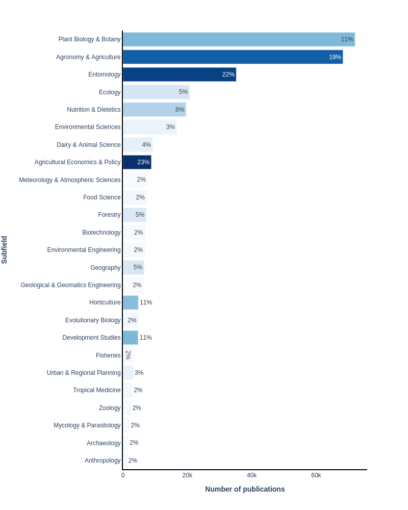

Figure 1. Top 25 subfields with the largest percentage of Scopus publication included in the publication set.

## Journals

In this section, we show how the publication set, captured by the query above, relates to scholarly journals. Journals are sorted in terms of their relevance using term frequency-inverse document frequency (TF-IDF). The horizontal bars are proportional to the number of publications contributed by the journal to the current publication set. The number alongside the horizontal bar is the proportion of the journal contributing to this publication set.

The articles on this topic are published most frequently in the following journals: *Acta Horticulturae* (7,509 publications), *PLoS ONE* (5,420), and *Sustainability (Switzerland)* (3,777).

Note, larger journals may not appear in the table below, as their SDG contribution may be relatively small compared to the size of the journal.

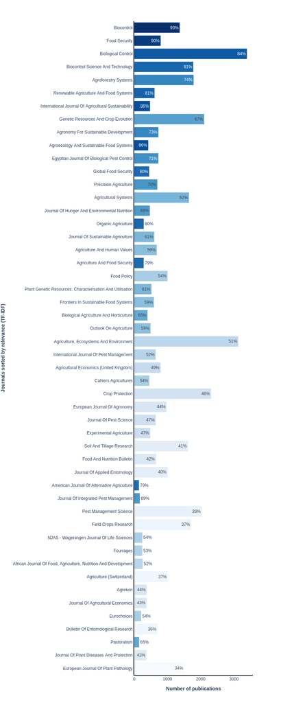

Figure 2. Top 50 journals, in terms of relevance (TF-IDF), for this publication set.

## Keywords

Elsevier’s [Scopus](https://www.scopus.com/search/form.uri?display=basic#basic) database of scientific literature, was used for the table below. The document types included in the data sets are journal articles, reviews, short surveys and conference papers, covering the period 1996–2022. We refer to these documents collectively as “publications” or “papers”.

In order to help better illustrate the content of this set of publications, indicators associated with the keywords most specific to this set (according to a TF-IDF score) are presented below.

|  | Term | # of papers with this term in the publication set | # of papers with this term in all of Scopus | Relevance (TF-IDF) | Percentage of Scopus |
| --- | --- | --- | --- | --- | --- |
| 1 | organic and conventional | 2768 | 3010 | 18.7435 | 92 |
| 2 | agri-environment | 2899 | 3179 | 18.7224 | 91 |
| 3 | agri-environmental | 1836 | 2037 | 18.7143 | 90 |
| 4 | conventional and organic | 1511 | 1666 | 18.7078 | 91 |
| 5 | crop-livestock | 1572 | 1749 | 18.6962 | 90 |
| 6 | household food insecurity | 1320 | 1455 | 18.6875 | 91 |
| 7 | risk of malnutrition | 2377 | 2678 | 18.6866 | 89 |
| 8 | agri-environment scheme | 916 | 965 | 18.6744 | 95 |
| 9 | organic management | 1037 | 1124 | 18.6624 | 92 |
| 10 | food insecure | 1802 | 2063 | 18.6552 | 87 |

[output cut: 990 more lines]